# Inventari Forestal Nacional 3: Lleida. Analisi i modelat

Autor: Xavier Pascuet

Gener 2021

# 1 Anàlisis exploratòria de dades

```r
# Importo les llibreries necessàries
library(arules)
library(ggplot2)
library(cluster)
library(factoextra)
library(dplyr)
library(caret)
# Importo el dataset
treeData <- read.csv("PC_lleida.csv")
```

```r
# Estructura del dataset
str(treeData)
```

```
## 'data.frame':    70216 obs. of  19 variables:
##  $ Estadillo: int  1 1 1 1 1 1 1 1 1 1 ...
##  $ Cla      : chr  "A" "A" "A" "A" ...
##  $ Subclase : chr  "1" "1" "1" "1" ...
##  $ nArbol   : int  1 2 3 4 5 6 7 8 9 10 ...
##  $ OrdenIf3 : int  1 2 3 4 888 5 6 7 8 9 ...
##  $ OrdenIf2 : int  1 2 3 4 5 6 7 8 10 9 ...
##  $ Rumbo    : int  59 100 102 103 109 114 165 174 175 175 ...
##  $ Distanci : num  29.3 30.7 17.1 17.6 17 ...
##  $ Especie  : int  71 71 71 31 31 71 71 71 71 71 ...
##  $ Dn1      : int  710 697 316 356 411 342 159 248 388 288 ...
##  $ Dn2      : int  710 697 321 318 404 359 174 256 405 283 ...
##  $ Ht       : num  21.1 20.5 17.4 18.9 0 ...
##  $ Calidad  : int  2 2 2 2 6 2 3 5 2 2 ...
##  $ Forma    : int  5 5 5 2 NA 2 5 5 5 5 ...
##  $ ParEsp   : int  NA NA NA NA NA NA 49 49 49 49 ...
##  $ Agente   : int  100 100 100 100 200 100 316 400 100 100 ...
##  $ Import   : int  NA NA NA NA 3 NA 2 3 NA NA ...
##  $ Elemento : int  NA NA NA NA 9 NA 9 9 NA NA ...
##  $ Compara  : chr  "X" "X" "X" "X" ...
```

El fitxer consta de 70216 observacions i 19 variables, la majoria de tipus númeric, encara que algunes d’aquestes són codificacions categòriques.

```r
# Visualitzo les estadístiques bàsiques
summary(treeData)
```

```
##    Estadillo        Cla              Subclase             nArbol
##  Min.   :   1   Length:70216       Length:70216       Min.   : 1.00
##  1st Qu.: 792   Class :character   Class :character   1st Qu.: 6.00
##  Median :1592   Mode  :character   Mode  :character   Median :13.00
##  Mean   :1709                                         Mean   :16.25
##  3rd Qu.:2458                                         3rd Qu.:23.00
##  Max.   :4375                                         Max.   :80.00
##
##     OrdenIf3         OrdenIf2          Rumbo        Distanci
##  Min.   :  0.00   Min.   :  0.00   Min.   :  0   Min.   : 0.000
##  1st Qu.:  5.00   1st Qu.:  0.00   1st Qu.: 85   1st Qu.: 4.500
##  Median : 13.00   Median :  4.00   Median :190   Median : 7.700
##  Mean   : 49.17   Mean   : 10.29   Mean   :189   Mean   : 8.104
##  3rd Qu.: 23.00   3rd Qu.: 14.00   3rd Qu.:292   3rd Qu.:10.600
##  Max.   :999.00   Max.   :999.00   Max.   :399   Max.   :36.500
##
##     Especie            Dn1              Dn2             Ht
##  Min.   :  4.00   Min.   :   0.0   Min.   :   0   Min.   : 0.000
##  1st Qu.: 21.00   1st Qu.: 137.0   1st Qu.: 137   1st Qu.: 6.700
##  Median : 24.00   Median : 195.0   Median : 195   Median : 9.700
##  Mean   : 46.16   Mean   : 217.4   Mean   : 217   Mean   : 9.831
##  3rd Qu.: 31.00   3rd Qu.: 272.0   3rd Qu.: 272   3rd Qu.:13.000
##  Max.   :757.00   Max.   :1706.0   Max.   :1706   Max.   :39.000
##  NA's   :3322
##     Calidad          Forma           ParEsp           Agente
##  Min.   :1.000   Min.   :1.000   Min.   :  41.0   Min.   :100.0
##  1st Qu.:2.000   1st Qu.:2.000   1st Qu.:  42.0   1st Qu.:100.0
##  Median :2.000   Median :2.000   Median :  42.0   Median :100.0
##  Mean   :2.413   Mean   :2.653   Mean   : 122.5   Mean   :155.9
##  3rd Qu.:2.000   3rd Qu.:3.000   3rd Qu.:  49.0   3rd Qu.:100.0
##  Max.   :6.000   Max.   :6.000   Max.   :3099.0   Max.   :423.0
##  NA's   :3322    NA's   :6065    NA's   :56262    NA's   :4315
##      Import         Elemento       Compara
##  Min.   :1.00    Min.   :1.00    Length:70216
##  1st Qu.:1.00    1st Qu.:4.00    Class :character
##  Median :2.00    Median :9.00    Mode  :character
##  Mean   :1.77    Mean   :7.33
##  3rd Qu.:3.00    3rd Qu.:9.00
##  Max.   :3.00    Max.   :9.00
##  NA's   :54185   NA's   :54185
```

El dataset consta de les següents variables:

- **Estadillo:** Tipus Enter. Identificador de la parcel·la.
- **Cla:** tipus String. Codi que determina si la parcel·la ja estava a l’IFN2, o si s’inventaria per primera vegada.
- **Subclasse:** Tipus String. Codi que determina el tipus de parcel·la
- **nArbol:** Tipus enter. Número de l’arbre dins de la parcel·la
- **OrdenIf3:** Tipus enter. Número d’ordre de l’arbre en l’IFN3.
- **OrdenIf2:** Tipus enter. Número d’ordre de l’arbre en l’IFN2.
- **Rumbo:** Tipus enter. Angle que formen la direcció nord i la linea que uneix arbre i centre de la parcel·la. En sentit de les agulles del rellotge.
- **Distanci:** Tipus numèric. Distància en metres al centre de la parcel·la.
- **Especie:** Tipus Enter. Codi de l’espècie arbòria. Dins de Lleida pren els següents valors:
  - 4: Rhamnus alaternus
  - 8: Phillyrea latifolia
  - 12: Malus sylvestris
  - 13: Celtis australis
  - 14: Taxus baccata
  - 15: Crataegus
  - 16: Pyrus spp.
  - 21: Pinus sylvestris
  - 22: Pinus uncinata
  - 23: Pinus pinea
  - 24: Pinus halepensis
  - 25: Pinus nigra
  - 26: Pinus pinaster
  - 31: Abies alba
  - 33: Picea abies
  - 36: Cupressus sempervirens
  - 37: Juniperus communis
  - 38: Juniperus thurifera
  - 39: Juniperus phoenicea
  - 41: Quercus robur
  - 42: Quercus petraea
  - 43: Quercus pyrenaica
  - 44: Quercus faginea
  - 45: Quercus ilex
  - 51: Populus alba
  - 52: Populus tremula
  - 54: Alnus glutinosa
  - 55: Fraxinus angustifolia
  - 56: Ulmus minor
  - 57: Salix spp.
  - 58: Populus nigra
  - 65: Ilex aquifolium
  - 66: Olea europaea
  - 68: Arbutus unedo
  - 71: Fagus sylvatica
  - 72: Castanea sativa
  - 73: Betula spp.
  - 74: Corylus avellana
  - 75: Juglans regia
  - 76: Acer campestre
  - 77: Tilia spp.
  - 78: Sorbus spp.
  - 91: Buxus sempervirens
  - 92: Robinia pseudacacia
  - 93: Pistacia terebinthus
  - 95: Prunus spp.
  - 97: Sambucus nigra
  - 99: Otras frondosas
  - 215: Crataegus monogyna
  - 235: Larix decidua
  - 236: Cupressus arizonica
  - 237: Juniperus oxycedrus
  - 243: Quercus pubescens
  - 255: Fraxinus excelsior
  - 256: Ulmus glabra
  - 257: Salix alba
  - 258: Populus x canadensis
  - 273: Betula alba
  - 275: Juglans nigra
  - 276: Acer monspessulanum
  - 277: Tilia cordata
  - 278: Sorbus aria
  - 295: Prunus spinosa
  - 297: Sambucus racemosa
  - 299: Ficus carica
  - 356: Ulmus pumila
  - 357: Salix atrocinerea
  - 373: Betula pendula
  - 377: Tilia platyphyllos
  - 378: Sorbus aucuparia
  - 395: Prunus avium
  - 476: Acer opalus
  - 576: Acer pseudoplatanus
  - 657: Salix caprea
  - 676: Acer platanoides
  - 757: Salix elaeagnos
- **Dn1:** Diàmetre normal del arbre apuntaant al centre de la parcel·la, en milímetres.
- **Dn2:** Diàmetre normal del arbre en driecció perpendicular a l’anterior, en milímetres.
- **Hf:** Tipus numèric, alçaça total de l’arbre en metres.
- **Calidad:** Tipus enter. Codifica la qualitat de l’arbre. Pot ser:
  - 1: Arbre sa, vigorós òptimament conformat ambg excelents perspectives de futur, capaç de proporcionar productes valuosos.
  - 2: Arbre sa, vigorós, no dominat amb algun defecte de conformació, capaç de proporcionar productes valuosos.
  - 3: Arbre no ttotalment sa i vigoros, vell o dominat pero capaç de proporcionar productes valuosos
  - 4: Arbre malalt i dèbil o vell, amb molts defectes de conformació, capaç de proporcionar productes de valor secundari
  - 5: Arbre molt malat, dèbil o vell, amb pèssima corformació y aprofitaments d’escas valor.
  - 6: Arbre mort pero sense podrir.
- **Forma:** Tipus enter. Codificac la forma de l’arbre.
  - 1: Arbres fusiformes en quasi la totalitat del troncm troncs fustaners de més de 6mm i diàmetre normal major de 20 cm.
  - 2: Arbres fusiformes, amb troncs fustaners de 4 metres o més, que no petanyen a la forma 1
  - 3: Arbres fusiformes petits, en els que el diàmetre de 75mm queda per sota els 4 metres d’alçada.
  - 4: Arbres amb el tronc ramificat abans dels 4 metres d’alçada.
  - 5: Arbres amb el tronc principal tortuos, sanyat o amb moltes rames.
  - 6: Arbres escapçats.
- **ParEsp:** Tipu ester. Parametres especials. Codifica la qualitat de suros o resines.
- **Agente:** Tipus enter. Codifica l’agent causant del dany. Pot ser:
  - 100: Sense danys
  - 200: Cause desconegudes
  - 310: Fongs
  - 311: Insectes
  - 312: Vesc
  - 313: Plantes epífites
  - 314: Fauna silvestre
  - 315: Bestiar
  - 320: Maquinària
  - 321: Treta de fusta
  - 322: Home en general
  - 410: Neu
  - 411: Vent
  - 412: Sequera
  - 413: LLamp
  - 414: Gelades
  - 415: Calamarsa
  - 421: Foc
  - 422: Despreniments
  - 423: Erosió
- **Import:** Tipus enter. Codifica la importància del dany. Pot ser:
  - 1: Petita
  - 2: Mitjana
  - 3: Gran
- **Elemento:** Tipus Enter. Codi referent a l’element danyat. Pot ser:
  - 1: Escorça
  - 2: Fulles
  - 3: Rames
  - 4: Tronc
  - 5: Fruits
  - 6: Flors
  - 7: Guía terminal
  - 8: Copa
  - 9: Arbre sencer
- **Compara:** Tipus String, codi d’ús intern.

#.- Preparació de dades

```r
#Visualitzo valors nulls
colSums(is.na(treeData))
```

```
## Estadillo       Cla  Subclase    nArbol  OrdenIf3  OrdenIf2     Rumbo  Distanci
##         0         0         0         0         0         0         0         0
##   Especie       Dn1       Dn2        Ht   Calidad     Forma    ParEsp    Agente
##      3322         0         0         0      3322      6065     56262      4315
##    Import  Elemento   Compara
##     54185     54185         0
```

Tinc molts valors nulls, dentre els que hem criden espècialment l’atenció els d’espècie i qualitat, exploro amb més detall.

```r
# Visualitza un resum de les dades amb nulls a èspecie i qualitat
summary(treeData[is.na(treeData$Especie),])
```

```
##    Estadillo        Cla              Subclase             nArbol
##  Min.   :  41   Length:3322        Length:3322        Min.   : 1.00
##  1st Qu.:1721   Class :character   Class :character   1st Qu.: 6.00
##  Median :2464   Mode  :character   Mode  :character   Median :13.00
##  Mean   :2227                                         Mean   :15.94
##  3rd Qu.:2948                                         3rd Qu.:22.00
##  Max.   :3343                                         Max.   :77.00
##
##     OrdenIf3    OrdenIf2         Rumbo      Distanci    Especie          Dn1
##  Min.   :0   Min.   : 1.00   Min.   :0   Min.   :0   Min.   : NA    Min.   :0
##  1st Qu.:0   1st Qu.: 6.00   1st Qu.:0   1st Qu.:0   1st Qu.: NA    1st Qu.:0
##  Median :0   Median :11.00   Median :0   Median :0   Median : NA    Median :0
##  Mean   :0   Mean   :14.03   Mean   :0   Mean   :0   Mean   :NaN    Mean   :0
##  3rd Qu.:0   3rd Qu.:19.00   3rd Qu.:0   3rd Qu.:0   3rd Qu.: NA    3rd Qu.:0
##  Max.   :0   Max.   :77.00   Max.   :0   Max.   :0   Max.   : NA    Max.   :0
##                                                      NA's   :3322
##       Dn2          Ht       Calidad         Forma          ParEsp
##  Min.   :0   Min.   :0   Min.   : NA    Min.   : NA    Min.   : NA
##  1st Qu.:0   1st Qu.:0   1st Qu.: NA    1st Qu.: NA    1st Qu.: NA
##  Median :0   Median :0   Median : NA    Median : NA    Median : NA
##  Mean   :0   Mean   :0   Mean   :NaN    Mean   :NaN    Mean   :NaN
##  3rd Qu.:0   3rd Qu.:0   3rd Qu.: NA    3rd Qu.: NA    3rd Qu.: NA
##  Max.   :0   Max.   :0   Max.   : NA    Max.   : NA    Max.   : NA
##                          NA's   :3322   NA's   :3322   NA's   :3322
##      Agente         Import        Elemento      Compara
##  Min.   : NA    Min.   : NA    Min.   : NA    Length:3322
##  1st Qu.: NA    1st Qu.: NA    1st Qu.: NA    Class :character
##  Median : NA    Median : NA    Median : NA    Mode  :character
##  Mean   :NaN    Mean   :NaN    Mean   :NaN
##  3rd Qu.: NA    3rd Qu.: NA    3rd Qu.: NA
##  Max.   : NA    Max.   : NA    Max.   : NA
##  NA's   :3322   NA's   :3322   NA's   :3322
```

S’observa que els que tenen espècie i qualitat null són arbres que es van inventariar en l’IFN2 i no s’han pogut inventariar el l’IFN3 (tenen Orden If3, diametres i alçada = 0). Com que vull centrar-me només amb dades de l’IFN3 i no m’interesa comparara dades amb l’IFN2, descarto aquests valors.

```r
# Elimino files amb espècie i qualitat nulls
treeData <- treeData[!is.na(treeData$Especie),]
```

Comprovo si queden valors de diametre= 0.

```r
colSums(treeData==0)
```

```
## Estadillo       Cla  Subclase    nArbol  OrdenIf3  OrdenIf2     Rumbo  Distanci
##         0         0         0         0         0     27906       243         3
##   Especie       Dn1       Dn2        Ht   Calidad     Forma    ParEsp    Agente
##         0         0         0      2743         0        NA        NA        NA
##    Import  Elemento   Compara
##        NA        NA         0
```

Es comprova que ja no queden valors de diàmatre = 0. Si que n’hi han d’alçada ja que hi han arbres tombats i morts.

Ara torno a mirar quins valors nulls hem queden.

```r
# Visualitzo valors nulls
colSums(is.na(treeData))
```

```
## Estadillo       Cla  Subclase    nArbol  OrdenIf3  OrdenIf2     Rumbo  Distanci
##         0         0         0         0         0         0         0         0
##   Especie       Dn1       Dn2        Ht   Calidad     Forma    ParEsp    Agente
##         0         0         0         0         0      2743     52940       993
##    Import  Elemento   Compara
##     50863     50863         0
```

Els valors de forma nulls corresponen a arbres tombats, per tal de facilitar la posterior aplicació de mètodes els codificare com a forma 7, seguint l’ordre establert. Hi han valors d’Agent, import i element nulls que corresponen a arbres que no presenten danys, els qualificare com a agent=100, import=0 i element=0, d’acord als les codificacions existents.

```r
# Codifico els nulls de forma
treeData$Forma[is.na(treeData$Forma)] <- 7
# Codifico els nulls d'agent
treeData$Agente[is.na(treeData$Agente)] <- 100
# Codifico els nulls d'Import
treeData$Import[is.na(treeData$Import)] <- 0
# Codifico els nulls d'element
treeData$Elemento[is.na(treeData$Elemento)] <- 0
# Comprovo que no quedin nulls en els camps d'interes
colSums(is.na(treeData))
```

```
## Estadillo       Cla  Subclase    nArbol  OrdenIf3  OrdenIf2     Rumbo  Distanci
##         0         0         0         0         0         0         0         0
##   Especie       Dn1       Dn2        Ht   Calidad     Forma    ParEsp    Agente
##         0         0         0         0         0         0     52940         0
##    Import  Elemento   Compara
##         0         0         0
```

Dn1 i Dn2 són les mesures de diàmetre perpendiculars entre elles, per tal de facilitar l’analisis creo una variable Dn que sigui la mitjana de les 2.

```r
# Creo variable Dn
treeData$Dn <- (treeData$Dn1 + treeData$Dn2) / 2
```

```r
# Importo el fitxer que conté la relació codi-nom de l'especie
codi_nom <- read.csv("codi_especies.csv", sep=";")

# Uneixo per obtenir els noms d'especies
treeData <- merge(treeData, codi_nom, by.x = "Especie", by.y = "Codi")
```

Finalment selecciono només les columnes d’interes

```r
treeData <- subset(treeData, select = c(Estadillo, nom_especie, Dn, Ht, Calidad, Forma))
```

# 2 Model de generació de regles d’associació

Un cop tinc les dades netes i amb les transformacions necesàries creo un objecte de tipus transaction, on cada transacció tindrà agrupades totes les èspecies arbòries (“especie”) que han sigut trobades en una mateixa parcel·la d’inventari (“estadillo”). En aquest cas hem convé eliminar duplicats, ja que busco items que ocorren de manera conjunta, no m’interesa la quantitat.

He consultat informació sobre l’us de la llibreria arules a: *Reglas de asociación y algoritmo Apriori con R.* [en línia][data de consulta: 30 de desembre de 2020]. Disponible a: https://rpubs.com/Joaquin_AR/397172

```r
# Creo llista de transaccions
dades_split <- split(x=treeData$nom_especie, f=treeData$Estadillo)
#Creo l'objecte transactions
transaccions <- as(dades_split, Class = "transactions")
```

Ara, ja tinc les dades en un format que l’algoritme apriori pot processar. Creo les regles d’associació establint una confiança del 50% i un suport del 1%:

```r
# Creo regles d'associació
tree_rules <- apriori(transaccions, parameter = list(support = 0.01, confidence = 0.5))
```

```
## Apriori
##
## Parameter specification:
##  confidence minval smax arem  aval originalSupport maxtime support minlen
##         0.5    0.1    1 none FALSE            TRUE       5    0.01      1
##  maxlen target  ext
##      10  rules TRUE
##
## Algorithmic control:
##  filter tree heap memopt load sort verbose
##     0.1 TRUE TRUE  FALSE TRUE    2    TRUE
##
## Absolute minimum support count: 31
##
## set item appearances ...[0 item(s)] done [0.00s].
## set transactions ...[76 item(s), 3173 transaction(s)] done [0.00s].
## sorting and recoding items ... [18 item(s)] done [0.00s].
## creating transaction tree ... done [0.00s].
## checking subsets of size 1 2 3 4 done [0.00s].
## writing ... [4 rule(s)] done [0.00s].
## creating S4 object  ... done [0.00s].
```

```r
# Observo un resum de les mesures de qualitat
summary(tree_rules)
```

```
## set of 4 rules
##
## rule length distribution (lhs + rhs):sizes
## 2
## 4
##
##    Min. 1st Qu.  Median    Mean 3rd Qu.    Max.
##       2       2       2       2       2       2
##
## summary of quality measures:
##     support          confidence        coverage            lift
##  Min.   :0.01040   Min.   :0.6000   Min.   :0.01450   Min.   :1.485
##  1st Qu.:0.01135   1st Qu.:0.6041   1st Qu.:0.01568   1st Qu.:1.691
##  Median :0.01481   Median :0.6614   Median :0.02301   Median :2.056
##  Mean   :0.01521   Mean   :0.6621   Mean   :0.02372   Mean   :3.688
##  3rd Qu.:0.01867   3rd Qu.:0.7194   3rd Qu.:0.03104   3rd Qu.:4.054
##  Max.   :0.02080   Max.   :0.7255   Max.   :0.03435   Max.   :9.153
##      count
##  Min.   :33.00
##  1st Qu.:36.00
##  Median :47.00
##  Mean   :48.25
##  3rd Qu.:59.25
##  Max.   :66.00
##
## mining info:
##          data ntransactions support confidence
##  transaccions          3173    0.01        0.5
##                                                                              call
##  apriori(data = transaccions, parameter = list(support = 0.01, confidence = 0.5))
```

Amb els paràmetres especificats, l’algoritme ha identificat 4 regles. Totes elles consten de 2 elements.

```r
# Ordeno per lift
inspect(head(sort(tree_rules, by="lift"), 4))
```

```
##     lhs                      rhs                support    confidence
## [1] {Fagus sylvatica }    => {Abies alba }      0.01796407 0.6000000
## [2] {Juniperus oxycedrus} => {Pinus nigra }     0.01166089 0.7254902
## [3] {Juniperus communis } => {Pinus sylvestris} 0.01040025 0.7173913
## [4] {Betula pendula}      => {Pinus sylvestris} 0.02080050 0.6055046
##     coverage   lift     count
## [1] 0.02994012 9.152885 57
## [2] 0.01607312 2.353763 37
## [3] 0.01449732 1.759106 33
## [4] 0.03435235 1.484750 66
```

Observo com amb un lift de 9,15, una confiança del 60% i un suport del 1’79%, en les parcel·les on es troba faig(Fagus sylvatica) també es troba avet(Abies alba).

També observo com amb un lift de 2,35, una confiança del 72,5 i un suport del 1,1 en les parcel·les on es troba ginebró (Juniperus oxycedrus) també es troba pinassa(Pinus nigra)

Ara vull trobar regles que incloguin com a mínim 3 arbres , per aixo haure de baixar el support (o la confiança), torno a aplicar l’algoritme per trobar regles, aquest cop indicant que, per a ser inclosa als resultats, cada regla ha de tenir com a mínim 3 espècies arbòries.

```r
tree_rules <- apriori(transaccions, parameter = list(support = 0.005, minlen=3, confidence = 0.5))
```

```
## Apriori
##
## Parameter specification:
##  confidence minval smax arem  aval originalSupport maxtime support minlen
##         0.5    0.1    1 none FALSE            TRUE       5   0.005      3
##  maxlen target  ext
##      10  rules TRUE
##
## Algorithmic control:
##  filter tree heap memopt load sort verbose
##     0.1 TRUE TRUE  FALSE TRUE    2    TRUE
##
## Absolute minimum support count: 15
##
## set item appearances ...[0 item(s)] done [0.00s].
## set transactions ...[76 item(s), 3173 transaction(s)] done [0.00s].
## sorting and recoding items ... [29 item(s)] done [0.00s].
## creating transaction tree ... done [0.00s].
## checking subsets of size 1 2 3 4 done [0.00s].
## writing ... [3 rule(s)] done [0.00s].
## creating S4 object  ... done [0.00s].
```

Amb els nous paràmetres, l’algoritme ha trobat 3 regles

```r
# Ordeno per confiança
inspect(head(sort(tree_rules, by="confidence"), 10))
```

```
##     lhs                                     rhs                support
## [1] {Pinus sylvestris, Quercus faginea } => {Pinus nigra }     0.007248661
## [2] {Juniperus oxycedrus, Quercus ilex } => {Pinus nigra }     0.005042546
## [3] {Betula pendula, Pinus uncinata }    => {Pinus sylvestris} 0.006618342
##     confidence coverage    lift     count
## [1] 0.6571429  0.011030570 2.132019 23
## [2] 0.5714286  0.008824456 1.853929 16
## [3] 0.5675676  0.011660889 1.391725 21
```

Observo com amb un lift de 2,13, suport de 0,7% i confiança del 65,7%, a les parcel·les on es troba pi roig(Pinus sylvestris) i roure de fulla petita(Quercus faginea) també s’hi troba pinassa(Pinus nigra).

Observo com amb un lift de 1,85, suport de 0,5% i confiança del 57,1%, a les parcel·les on es troba ginebro(Juniperus oxycedrus) i alzina(Quercus ilex) també s’hi troba pinassa(Pinus nigra).

Observo com amb un lift de 1,39, suport de 0,6% i confiança del 56,7%, a les parcel·les on es troba bedoll(Betula pendula) i pi negre(Pinus uncinata) també s’hi troba pi roig(Pinus sylvestrus).

# 3 Model no supervisat basat en distàncies (CLARA)

Per tal de transformar el problema en un de no supervisat, no utilitzo la columna espècie, que es la variable que vull predir. Selecciono les variables que son càracterístiques dels individus.

```r
# Selecciono valors d'interes
x <- subset(treeData, select = c(Dn, Ht, Calidad, Forma))
```

He consultat diferents mètodes de clustering basats en distàncies a: *Clustering y heatmaps*: Aprendizaje no supervisado[en línia][data de consulta: 2 de gener de 2021]. Disponible a https://www.cienciadedatos.net/documentos/37_clustering_y_heatmaps#Hierarchical_clustering He consultat el funcionament de l’algoritme clara a:R Documentation: *clara*[en línia][data de consulta: 2 de gener de 2021] Disponible a: https://www.rdocumentation.org/packages/cluster/versions/2.1.0/topics/clara

Aplico l’algoritme clara, que combina idea de K-medoides amb un resampling per tal que es pugui aplicar a grans volums de dades.

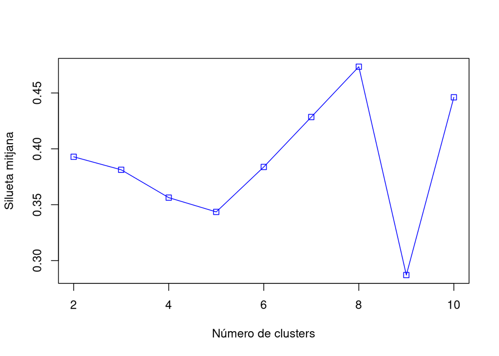

```r
# Defineixo llavor
set.seed(22)
# Vector que contindrà resultats
resultats <- rep(0, 10)
# Crido clara per diferents nombres de clusters i enmagatzemo la silueta mitjana
for (i in c(2,3,4,5,6,7,8,9,10))
{
  tree_clusters <- clara(x, i, stand=TRUE, samples = 50, pamLike = TRUE)
  resultats[i] <- tree_clusters$silinfo$avg.width
}
#Representació gràfica
plot(2:10,resultats[2:10],type="o",col="blue",pch=0,xlab="Número de clusters",ylab="Silueta mitjana")
```

Utilitzant el criteri de la silueta mitjana, el nombre més adequat de clusters són 8, ja que la mitjana del valor de les siluetes es més propera a 1.

```r
# Agrupo mitjançant clara amb 8 clusters
tree_clusters_eucl <- clara(x, 8, stand=TRUE, samples = 50, pamLike = TRUE)
# Afegeixo la columna del cluster a una copia del dataframe
x_results <- x
x_results[["cluster_cle"]] <- tree_clusters_eucl$clustering
# Emmagatzemo la silueta mitjana
s_cle <- tree_clusters_eucl$silinfo$avg.width
tree_clusters_eucl
```

```
## Call:     clara(x = x, k = 8, stand = TRUE, samples = 50, pamLike = TRUE)
## Medoids:
##          Dn   Ht Calidad Forma
## 57159  82.5  6.0       3     5
## 57689 154.5  7.0       2     5
## 5448  172.5  0.0       6     7
## 45886 180.0  8.5       2     2
## 19891 441.0 16.5       2     2
## 31832 250.0 13.5       2     2
## 54416 164.0  8.5       3     2
## 45639 111.0  7.0       2     3
## Objective function:   0.9567441
## Clustering vector:    Named int [1:66894] 1 1 1 1 2 1 2 3 2 2 1 2 1 2 3 1 1 4 ...
##  - attr(*, "names")= chr [1:66894] "1" "2" "3" "4" "5" "6" "7" ...
## Cluster sizes:            3904 6137 3087 14479 7737 18466 6505 6579
## Best sample:
##  [1] 1603  1839  2079  2489  3440  4746  5448  8245  9328  12849 18528 19891
## [13] 20016 22061 22326 24098 24162 26591 31150 31160 31832 33002 33285 34662
## [25] 35299 35368 35614 36003 38058 38342 38432 39208 39798 42249 42752 43886
## [37] 45602 45639 45886 46137 46340 48705 50500 50818 50955 54416 55885 56937
## [49] 57159 57689 57883 59817 61885 63825 65324 66334
##
## Available components:
##  [1] "sample"     "medoids"    "i.med"      "clustering" "objective"
##  [6] "clusinfo"   "diss"       "call"       "silinfo"    "data"
```

S’han creat 8 grups, de diferents tamanys i característiques diferenciades:

- 1: Arbres de poca alçada i molt poc diàmetres, sans i dominats pel que fa a qualitat i amb el tronc tort o molt ramificat.
- 2: Arbres de poca alçada i diàmetre mig, sans, no dominats i amb el tronc tort o molt ramificat.
- 3: Arbres morts.
- 4: Arbres de poca alçada i diàmetre gran, sans, no dominats i amb el tronc fusiforme.
- 5: Arbres de gran alçada i diàmetre, sans i no dominats i amb el tronc fusiforme.
- 6: Arbres d’alçada i diàmetre mitjans, sans i no dominats i amb el tronc fusiforme.
- 7: Arbres de poca alçada i diàmetre mig, dominats i amb el tronc fusiforme.
- 8: Arbres de poca alçada i diàmetre, sans, no dominats i amb el tronc fusiforme.

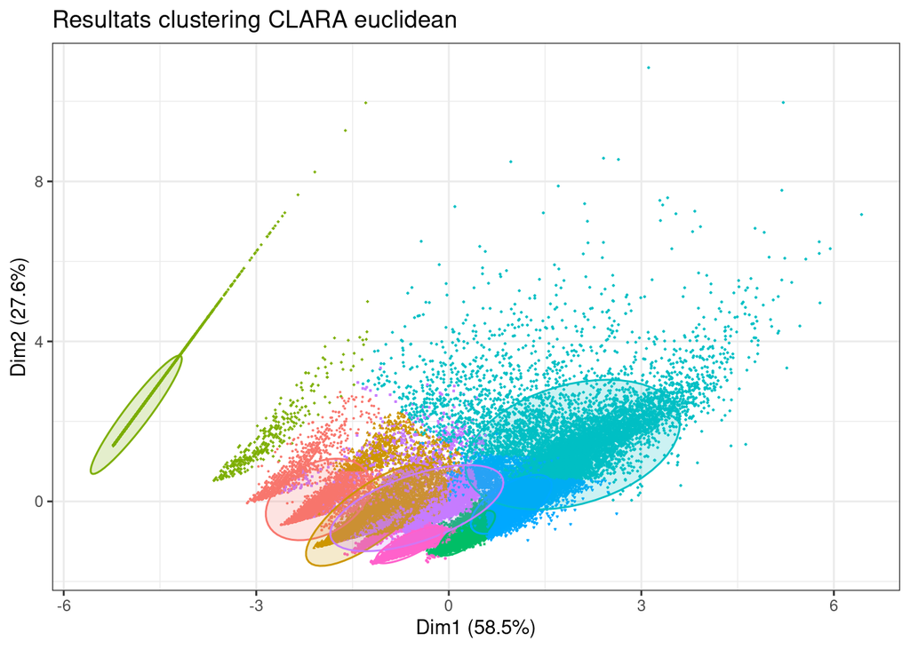

```r
# Visualitxo la distribució dels clusters segons PCA
fviz_cluster(object = tree_clusters_eucl, ellipse.type = "t", geom = "point", pointsize = 0.01) +
  theme_bw() + labs(title = "Resultats clustering CLARA euclidean") + theme(legend.position = "none")
```

Degut a la gran quantitat de registres dels que disposa el dataset, es una mica dificil d’interpretar, pero sembla que tenim molts outliners i també superposició de clusters.

Vegem que que passa si afegeixo la columna categòrica (espècie) i comprobo resultats.

```r
# Afegeixo la columna amb els noms d'espècies
x_results[["especie"]] <- treeData$nom_especie
# Reordeno columnes
x_results <- x_results[, c(1, 2, 3, 4, 6, 5)]
# Dataframe amb els clusters i les especies
cluster_especie <- x_results %>% group_by(cluster_cle, especie) %>% summarise(number = n())
print.data.frame(cluster_especie)
```

```
##     cluster_cle                 especie number
## 1             1             Abies alba      30
## 2             1          Acer campestre      6
## 3             1     Acer monspessulanum     22
## 4             1             Acer opalus      2
## 5             1        Acer platanoides      3
## 6             1         Alnus glutinosa      6
## 7             1           Arbutus unedo     27
## 8             1             Betula alba     16
## 9             1          Betula pendula     68
## 10            1            Betula spp.      73
## 11            1     Buxus sempervirens       1
## 12            1        Celtis australis      2
## 13            1       Corylus avellana      48
## 14            1               Crataegus      5
```

[output cut: 367 more lines]

A priori no sembla que hi hagi diferències significatives pel que fa la distribució d’espècies entre clusters, mirarè de desfer-me dels possibles outliers.

```r
# Selecciono aquelles espècies que tinguin com a mínim 5 exemplars dins dels clusters
cluster_especie <-cluster_especie[cluster_especie[, "number"] >= 5,]
print.data.frame(cluster_especie)
```

```
##     cluster_cle                especie number
## 1             1            Abies alba      30
## 2             1         Acer campestre      6
## 3             1    Acer monspessulanum     22
## 4             1        Alnus glutinosa      6
## 5             1          Arbutus unedo     27
## 6             1            Betula alba     16
## 7             1         Betula pendula     68
## 8             1           Betula spp.      73
## 9             1      Corylus avellana      48
## 10            1              Crataegus      5
## 11            1     Crataegus monogyna      8
## 12            1       Fagus sylvatica      75
## 13            1 Fraxinus angustifolia      10
## 14            1     Fraxinus excelsior     16
```

[output cut: 225 more lines]

Encara es dificil d’extreure conclusions, utilitzaré les frequències per espècie d’arbres present en el cluster respecte al nombre total.

```r
# Dataframe amb el total d'individus per espècie
n_especies <- x_results %>% group_by(especie) %>% summarise(totals = n())
# Afegeixo els totals al quadre cluster/especie
cluster_especie <- merge(cluster_especie, n_especies, by.x = "especie", by.y = "especie")
# Calculo la freqüència relativa al total
cluster_especie[["frequencia"]] <- (cluster_especie$number / cluster_especie$totals)
# Selecciono els de frequencia >= 0.02
cluster_especie <- cluster_especie[cluster_especie[, "frequencia"] >= 0.2,]
# Ordeno per cluster
cluster_especie[order(cluster_especie$cluster_cle),]
```

```
##                    especie cluster_cle number totals frequencia
## 15     Acer monspessulanum           1     22    101  0.2178218
## 29           Arbutus unedo           1     27     49  0.5510204
## 46            Betula spp.            1     73    356  0.2050562
## 57       Corylus avellana            1     48     99  0.4848485
## 62               Crataegus           1      5     10  0.5000000
## 65      Crataegus monogyna           1      8     33  0.2424242
## 95     Juniperus communis            1     22     60  0.3666667
## 100    Juniperus oxycedrus           1     21     81  0.2592593
## 103   Juniperus phoenicea            1     19     58  0.3275862
## 107      Malus sylvestris            1      7     12  0.5833333
## 108          Olea europaea           1     16     43  0.3720930
## 111   Phillyrea latifolia            1      6     14  0.4285714
## 184          Quercus ilex            1   1271   4383  0.2899840
## 208          Quercus robur           1      9     36  0.2500000
```

[output cut: 80 more lines]

Ara si que s’observen diferencies significatives pel que fa la distribució d’espècies en els clusters:

- Cluster 1: Destaca la completa absència de coníferes i la important presència d’alzina(Quercus ilex) i de pseudoarbustos com l’arboç(Arbutus unedo), l’avellanes (Corylus avellana), els ginebrons(Juniperus sp.) i diverses espècies del gènere Salix
- Cluster 2: Destaca la completa absència de coníferes(amb l’excepció del pi pinyoner (Pinus pinea)) i la important presència d’alzina(Quercus ilex), de roure martinent (Quercus humilis), roure de fulla petita(Quercus faginea), bedolls(Betula sp), aurons(Acer sp) moixeres(Sorbus sp) i algun pseudoarbust.
- Cluster 3: Conté unicament uns quants planifolis, l’olivera (Olea Europaea), el cirerer(Prunus avium), salze (Salix sp), oms (Ulmus minor) i moixeres.
- Cluster 4: Conté principalment pins com el roig(Pinus sylvestris), la pinassa (pinus nigra), el blanc(Pinus halepensis i el maritim(Pinus pinaster).
- Cluster 5: Conté majoritàriament avets (Abies alba) així com el faig(Fagus Sylvatica) i algunes espècies de pollancres (Populus sp)
- Cluster 6: Conté principalment pins pirinencs com el negre (Pinus uncinata), el roig(Pinus sylvestris), la pinassa(Pinus nigra), aixi com avets(Abies alba), faig(Fagus sylvatica), bedoll(betula pendula), freixes(Fraxinus sp.) tremol(Populus tremula) i d’altres planifolis.
- Cluster 7: Conté només planifolis coneguts com a fustes nobles, el noguer(Juglans regia), el cirerer(Prunus avium) i el lledoner(Celtis australis).
- Cluster 8: Conté únicament pseudoarbustos com les moixeres (Sorbus sp.), el boix(Buxus sempervirens), el grèvol(Ilex aquifollium), el ginebro(Juniperus oxycedrus), la sabina(Juniperus phoenicea) i la blada (Acer opalus).

# 4 Model no supervisat canviant la mètrica

L’algoritme CLARA utilitza per defecte la distància euclideana, vegem que pasa si, en el seu lloc, fem servir la distància de manhattan com a mètrica.

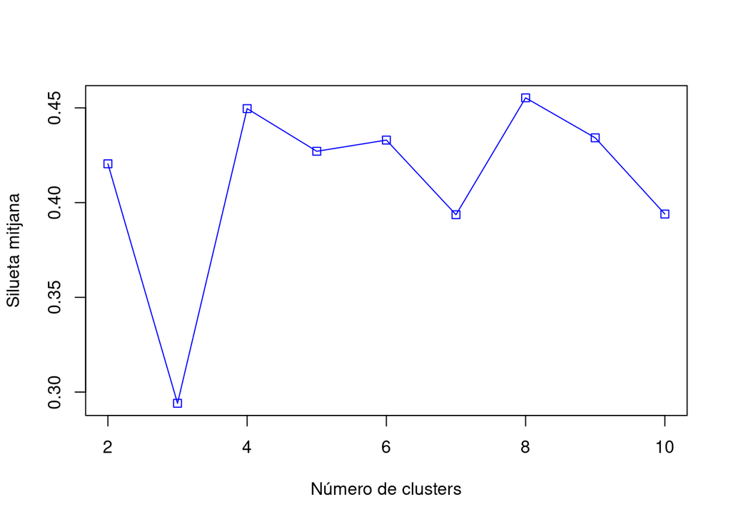

```r
# Defineixo llavor
set.seed(22)
# Vector que contindrà resultats
resultats <- rep(0, 10)
# Crido clara per diferents nombres de clusters i enmagatzemo la silueta mitjana
for (i in c(2,3,4,5,6,7,8,9,10))
{
  tree_clusters <- clara(x, i, metric="manhattan", stand=TRUE, samples = 50, pamLike = TRUE)
  resultats[i] <- tree_clusters$silinfo$avg.width
}
#Representació gràfica
plot(2:10,resultats[2:10],type="o",col="blue",pch=0,xlab="Número de clusters",ylab="Silueta mitjana")
```

Utilitzant la distància de manhattan i el criteri de la silueta mitjana, el nombre més adequat de clusters són també 8, ja que la mitjana del valor de les siluetes es més propera a 1.

```r
# Agrupo mitjançant clara amb 8 clusters
tree_clusters_manh <- clara(x, 8, metric= "manhattan", stand=TRUE, samples = 50, pamLike = TRUE)
# Afegeixo la columna del cluster
x_results[["cluster_clm"]] <- tree_clusters_manh$clustering
# Emmagatzemo la silueta mitjana
s_clm <- tree_clusters_manh$silinfo$avg.width
tree_clusters_manh
```

```
## Call:     clara(x = x, k = 8, metric = "manhattan", stand = TRUE, samples = 50,      pamLike = TRUE)
## Medoids:
##          Dn   Ht Calidad Forma
## 59107 167.0  5.0       3     5
## 57291 166.5  6.0       2     5
## 33783 200.5  0.0       6     7
## 11664 160.0 10.4       2     2
## 12621 283.5 14.0       2     2
## 28876 212.0 10.0       3     2
## 50292 433.5 20.0       2     2
## 50469  96.0  6.5       2     3
## Objective function:   1.239425
## Clustering vector:    Named int [1:66894] 1 1 1 1 2 1 2 3 2 2 1 2 1 2 3 1 1 4 ...
##  - attr(*, "names")= chr [1:66894] "1" "2" "3" "4" "5" "6" "7" ...
## Cluster sizes:            5336 5592 2747 17875 16127 5562 5656 7999
## Best sample:
##  [1] 1665  5374  9736  10017 10055 10744 11664 12621 12754 13848 15030 15121
## [13] 16925 17461 17543 20559 22480 22843 25504 25571 26072 26709 27422 28114
## [25] 28209 28876 29185 30876 32187 33783 34003 34375 34503 35297 36556 38980
## [37] 40593 42524 44516 46740 49053 50292 50469 51308 52498 53563 57291 57537
## [49] 58633 59107 59416 60793 62134 63588 64562 64655
##
## Available components:
##  [1] "sample"     "medoids"    "i.med"      "clustering" "objective"
##  [6] "clusinfo"   "diss"       "call"       "silinfo"    "data"
```

S’han creat 8 grups, de diferents tamanys i característiques diferenciades, una mica diferents als obtinguts per la distància euclideana, principalment sembla que hi ha un grup amb dimensions mes grans i es simplifuiquen els grups de petites dimensions:

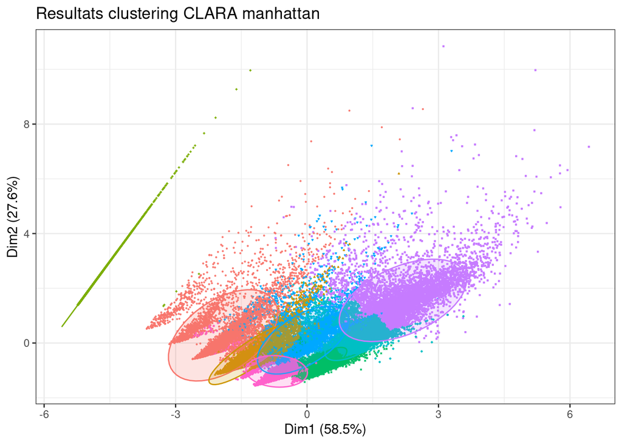

```r
# Visualitzo la distribució dels clusters segons PCA
fviz_cluster(object = tree_clusters_manh, ellipse.type = "t", geom = "point", pointsize = 0.1) +
  theme_bw() + labs(title = "Resultats clustering CLARA manhattan") + theme(legend.position = "none")
```

Obtenim un gràfic similar al obtingut anteriorment, una mica dificil d’interpretar, pero sembla que tenim molts outliners i també superposició de clusters.

Vegem que que passa si comprobo resultats, afegint la columna de classe.

```r
# Dataframe amb els clusters i les especies
cluster_especie_manh <- x_results %>% group_by(cluster_clm, especie) %>% summarise(number = n())
# Selecciono aquelles espècies que tinguin com a mínim 5 exemplars dins dels clusters
cluster_especie_manh <-cluster_especie_manh[cluster_especie_manh[, "number"] >= 5,]
# Afegeixo els totals al quadre cluster/especie
cluster_especie_manh <- merge(cluster_especie_manh, n_especies, by.x = "especie", by.y = "especie")
# Calculo la freqüència relativa al total
cluster_especie_manh[["frequencia"]] <- (cluster_especie_manh$number / cluster_especie_manh$totals)
# Selecciono els de frequencia >= 0.02
cluster_especie_manh <- cluster_especie_manh[cluster_especie_manh[, "frequencia"] >= 0.2,]
# Ordeno per cluster
cluster_especie_manh[order(cluster_especie_manh$cluster_clm),]
```

```
##                    especie cluster_clm number totals frequencia
## 10          Acer campestre           1     13     33  0.3939394
## 15     Acer monspessulanum           1     27    101  0.2673267
## 29           Arbutus unedo           1     30     49  0.6122449
## 48            Betula spp.            1     89    356  0.2500000
## 60       Corylus avellana            1     50     99  0.5050505
## 63               Crataegus           1      5     10  0.5000000
## 65      Crataegus monogyna           1     11     33  0.3333333
## 93     Juniperus communis            1     22     60  0.3666667
## 97     Juniperus oxycedrus           1     23     81  0.2839506
## 101   Juniperus phoenicea            1     20     58  0.3448276
## 104      Malus sylvestris            1      7     12  0.5833333
## 106          Olea europaea           1     34     43  0.7906977
## 108   Phillyrea latifolia            1      6     14  0.4285714
## 185          Quercus ilex            1   1372   4383  0.3130276
```

[output cut: 83 more lines]

Ara si que s’observen clarament diferencies significatives pel que fa la distribució d’espècies en els clusters:

- Cluster 1: Destaca la completa absència de coníferes i la important presència d’alzina(Quercus ilex) i de pseudoarbustos com l’arboç(Arbutus unedo), l’avellanes (Corylus avellana), els ginebrons(Juniperus sp.) i diverses espècies del gènere Salix. Molt similiar a l’obtingut per distància euclideana.
- Cluster 2: Destaca la completa absència de coníferes(amb l’excepció del pi pinyoner (Pinus pinea)) i la important presència d’alzina(Quercus ilex), de roure martinent (Quercus humilis), roure de fulla petita(Quercus faginea), bedolls(Betula sp), aurons(Acer sp) moixeres(Sorbus sp) i algun pseudoarbust. Molt similiar a l’obtingut per distància euclideana.
- Cluster 3: Conté unicament uns quants planifolis, l’olivera (Olea Europaea), el cirerer(Prunus avium), salze (Salix sp), oms (Ulmus minor) i moixeres. Molt similiar a l’obtingut per distància euclideana.
- Cluster 4: Conté principalment pins com el roig(Pinus sylvestris), la pinassa (pinus nigra), el blanc(Pinus halepensis i el maritim(Pinus pinaster) i també el roure martinenc. A diferencia de l’obtingut per distància euclideana incorpora molts roures
- Cluster 5: Conté majoritàriament avets (Abies alba) així com el faig(Fagus Sylvatica) i pins pirinencs com el negre (Pinus uncinata), el roig(Pinus sylvestris), la pinassa(Pinus nigra). A diferència del obtingut per distància euclideana no te tans pollancres (Populus sp) i té molts pins pirinencs.
- Cluster 6: Conté només 2 planifolis, el noguer(Juglans regia)i el lledoner(Celtis australis). Completament diferents a l’obtingut per distància euclideana.
- Cluster 7: Conté majoritàriament avets (Abies alba) així com el faig(Fagus Sylvatica) i pollancres (Populus sp). Completament diferents a l’obtingut per distància euclideana.
- Cluster 8: Conté principalment pseudoarbustos com les moixeres (Sorbus sp.), el boix(Buxus sempervirens), el grèvol(Ilex aquifollium), el ginebro(Juniperus oxycedrus), la sabina(Juniperus phoenicea) i la blada (Acer opalus) i també el ruore martinenc(Quercus humilis) i de fulla estreta (Quercus petraea). A diferència de l’obtingut per distància euclideana incorpora el roure martinenc i el de fulla estreta

## 4.1 Comparativa de resultats

```r
# Creo el quadre de amb els resultats obtinguts
comp_res <- data.frame(mean_silhouette=c(s_cle, s_clm))
# Anomeno els index
rownames(comp_res) <- c("Euclidean","Manhattan")
# Afegeixo els tamanys de cada cluster
for (i in c(1,2,3,4,5,6,7,8)){
comp_res[paste("cluster", i, "_size")]=colSums(x_results[,c(6:7)]==as.numeric(i))
}
print(comp_res)
```

```
##           mean_silhouette cluster 1 _size cluster 2 _size cluster 3 _size
## Euclidean       0.4734719            3904            6137            3087
## Manhattan       0.4553020            5336            5592            2747
##           cluster 4 _size cluster 5 _size cluster 6 _size cluster 7 _size
## Euclidean           14479            7737           18466            6505
## Manhattan           17875           16127            5562            5656
##           cluster 8 _size
## Euclidean            6579
## Manhattan            7999
```

Tant l’euclideana com la de manhattan donen 8 com a nombre òptim de clusters, amb una mitjana de les siluetes molt similar. No obstant si entrem a mirar tamanys i les característiques mitjanes de cada cluster si que trobem diferències, que s’accentuen més quan fem la comprovació de quines espècies ha assignat a cada cluster.

```r
# Creo columna com la diferencia de clusters
x_results$diff <- x_results$cluster_cle - x_results$cluster_clm
# Sumo registres que canvien el nª de cluster
colSums(x_results[8]!=0)
```

```
##  diff
## 32463
```

S’observa que només gairebé la meitat (32463 dels 66894 registres) canvien de cluster segons si s’utilitza la distància euclediana com a mètrica o si al contrari utilitzem la distància de manhattan.

En termes generals la mitjana del valor de les siluetes no es massa elevada, els clusters es sobreposen bastant i hi han valors molt allunyats dels centres dels clusters. En dataset escollit no sembla molt idoni per aplicar clustering, la classificació supervisada pot ser encara més dificil, ja que pel que sembla hi han característiques comunes per grups d’especies, podria ser més o menys facil predir a quin grup ha d’estar un registres, pero l’èspecie exacta sembla bastant complicat.

# 5 Model supervisat

L’objectiu es trobar un model que a partir de les característiques fisiologiques d’un arbre, pugui predir la seva espècie.

Observo la distribució de la variable de classe

```r
percentatge <- prop.table(table(treeData$nom_especie)) * 100
cbind(freq=table(treeData$nom_especie), percentatge=percentatge)
```

```
##                          freq  percentatge
## Abies alba               3588  5.363709750
## Acer campestre             33  0.049331779
## Acer monspessulanum       101  0.150985141
## Acer opalus                41  0.061290998
## Acer platanoides           29  0.043352169
## Acer pseudoplatanus         1  0.001494902
## Alnus glutinosa            77  0.115107483
## Arbutus unedo              49  0.073250217
## Betula alba               108  0.161449457
## Betula pendula            626  0.935808892
## Betula spp.               356  0.532185248
## Buxus sempervirens          9  0.013454121
## Castanea sativa             1  0.001494902
## Celtis australis           35  0.052321583
## Corylus avellana           99  0.147995336
## Crataegus                  10  0.014949024
## Crataegus monogyna         33  0.049331779
## Cupressus arizonica         2  0.002989805
## Cupressus sempervirens      1  0.001494902
## Fagus sylvatica           944  1.411187849
## Ficus carica                3  0.004484707
## Fraxinus angustifolia      84  0.125571800
## Fraxinus excelsior        263  0.393159327
## Ilex aquifolium            11  0.016443926
## Juglans nigra               5  0.007474512
## Juglans regia              25  0.037372560
## Juniperus communis         60  0.089694143
## Juniperus oxycedrus        81  0.121087093
## Juniperus phoenicea        58  0.086704338
## Juniperus thurifera         4  0.005979610
## Larix decidua              25  0.037372560
## Malus sylvestris           12  0.017938829
## Olea europaea              43  0.064280802
## Otras frondosas             1  0.001494902
## Phillyrea latifolia        14  0.020928633
## Picea abies                 1  0.001494902
## Pinus halepensis         2531  3.783597931
## Pinus nigra             13440 20.091488026
## Pinus pinaster            106  0.158459653
```

[output cut: 22 more lines]

```
## Salix caprea               45  0.067270607
## Salix elaeagnos             3  0.004484707
## Salix spp.                 12  0.017938829
## Sambucus nigra              9  0.013454121
## Sambucus racemosa           1  0.001494902
## Sorbus aria                61  0.091189045
## Sorbus aucuparia           95  0.142015726
## Sorbus spp.                18  0.026908243
## Taxus baccata               1  0.001494902
## Tilia cordata               3  0.004484707
## Tilia platyphyllos         29  0.043352169
## Tilia spp.                 25  0.037372560
## Ulmus glabra               13  0.019433731
## Ulmus minor                28  0.041857267
## Ulmus pumila                1  0.001494902
```

S’observa que hi ha algunes espècies amb molt pocs arbres en el dataset, que corresponen a fruiters naturalitzats, arbustos que han assolit excepcionalment la forma d’arbre, arbres ornamentals que deuen haver estat plantats i excepcions fora de la seva àrea natural de distribució. Estableixo un nombre mínim de 30 exemplars per espècie per tal de tenir-la encompte aixi hem desfaig d’aquests casos, i tinc suficients dades per especie de cara a entrenar els models.

```r
# Dataframe amb el recompte d'exemplars per especie
especie_count <- treeData %>% group_by(nom_especie) %>% summarise(number = n())
# Selecciono aquelles espècies que tinguin com a mínim 30 exemplars
especie_count <- especie_count [especie_count[, "number"] >= 30,]
# Selecciono del dataset
treeData<- merge(treeData, especie_count, by.x = "nom_especie", by.y = "nom_especie")
```

Selecciono només les columnes d’interes

```r
# Selecciono les columnes característiques i la variable a predir
dades_arbre <- subset(treeData, select = c(Dn, Ht, Calidad, Forma, nom_especie))
```

Parteixo el dataset en una part de train que contingui el 80% dels registres i el test la resta

```r
# create a list of 80% of the rows in the original dataset we can use for training
test_index <- createDataPartition(dades_arbre$nom_especie, p=0.80, list=FALSE)
# select 20% of the data for validation
test <- dades_arbre[-test_index,]
# use the remaining 80% of data to training and testing the models
train <- dades_arbre[test_index,]
```

Comprovo que no hi ha esbiaix en les particions dels conjunts de train i test i que conserven aproximadament les proporcions dels valors del dataset original, per cada variable:

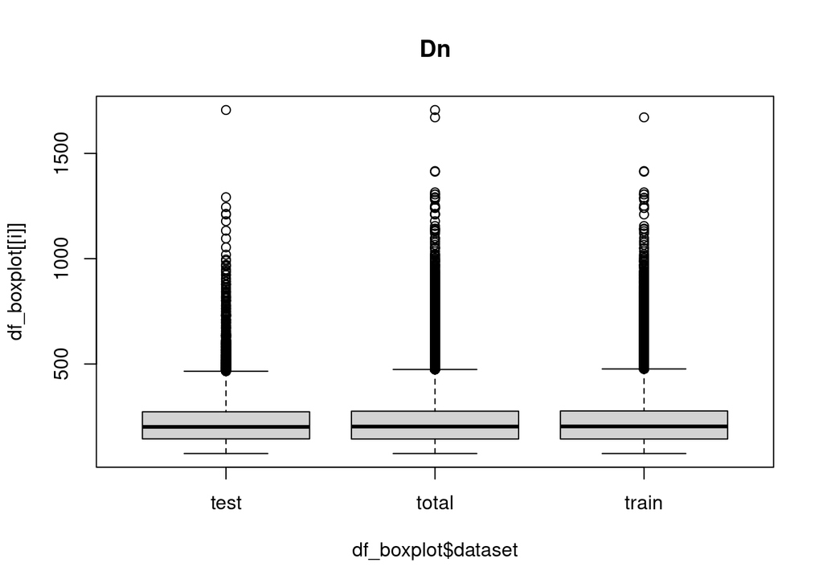

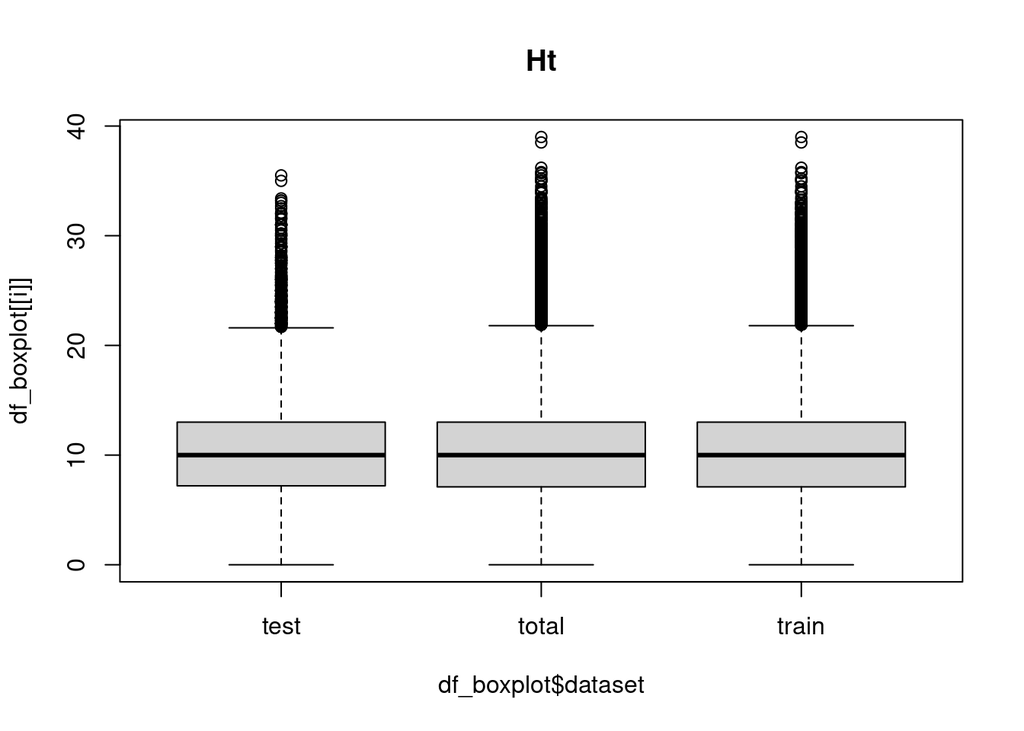

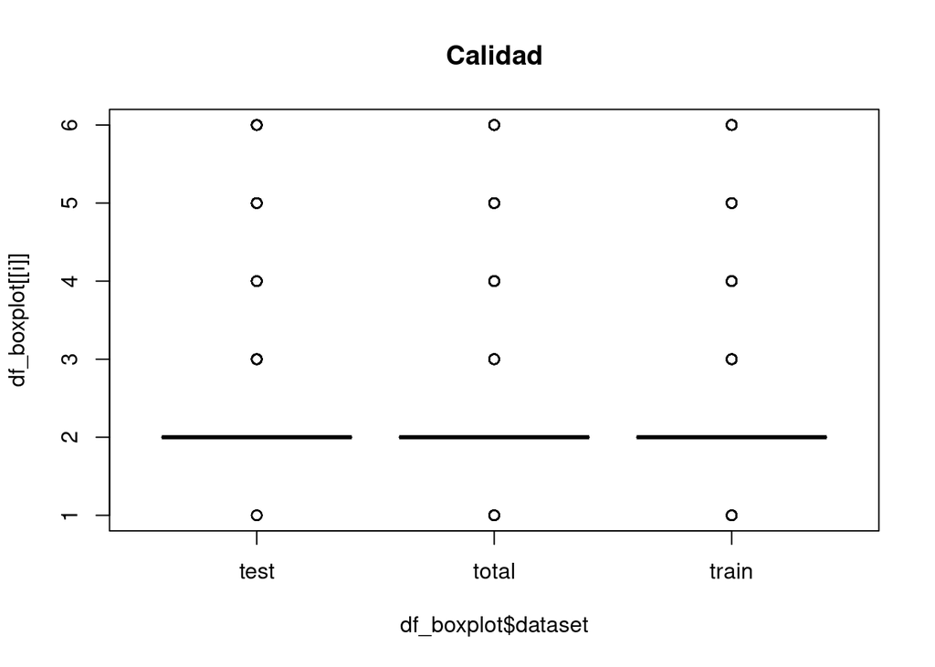

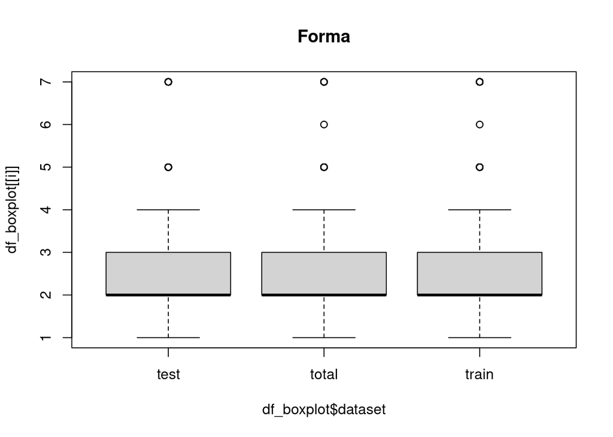

```r
# Genero el gràfic
df_boxplot <- rbind(dades_arbre, train, test)
df_boxplot <- cbind(df_boxplot, dataset = c(rep("total", nrow(dades_arbre)),
                                           rep("train", nrow(train)),
                                           rep("test",nrow(test))))
for (i in 1:4){
    boxplot(df_boxplot[[i]] ~ df_boxplot$dataset, main=colnames(df_boxplot)[i])
}
```

No s’observen diferències significatives entre els conjunts train i set.

```r
# Estableixo una validació per cross-validation amb 10 particions i la precisió com a mètrica
control <- trainControl(method="cv", number=10)
metrica <- "Accuracy"
```

Ara ja puc entrenar els models, n’entrenare 3 de diferents abans d’escullir el més precís.

```r
# a) Algoritmes linears (lda)
set.seed(7)
fit.lda <- train(nom_especie~., data=dades_arbre, method="lda", metric=metrica, trControl=control)
# b) Algoritmes no-linears
# CART
set.seed(7)
fit.cart <- train(nom_especie~., data=dades_arbre, method="rpart", metric=metrica, trControl=control)
# kNN
set.seed(7)
fit.knn <- train(nom_especie~., data=dades_arbre, method="knn", metric=metrica, trControl=control)
```

Ara ja tinc 3 models entrenats amb les respectives precisions, comparo els resultats

```r
# Comparo la precisió dels models
resultats <- resamples(list(lda=fit.lda, cart=fit.cart, knn=fit.knn))
summary(resultats)
```

```
##
## Call:
## summary.resamples(object = resultats)
##
## Models: lda, cart, knn
## Number of resamples: 10
##
## Accuracy
##           Min.   1st Qu.    Median      Mean   3rd Qu.      Max. NA's
## lda  0.3666015 0.3696807 0.3753758 0.3741783 0.3775773 0.3830778    0
## cart 0.3486556 0.3608523 0.3635407 0.3638680 0.3717023 0.3746619    0
## knn  0.3584197 0.3603502 0.3623726 0.3628002 0.3649141 0.3677487    0
##
## Kappa
##           Min.   1st Qu.    Median      Mean   3rd Qu.      Max. NA's
## lda  0.1533899 0.1605331 0.1693002 0.1668544 0.1715631 0.1771726    0
## cart 0.1106631 0.1305257 0.1339056 0.1323728 0.1403474 0.1448171    0
## knn  0.1679447 0.1716260 0.1731225 0.1737114 0.1768245 0.1780737    0
```

Tots tenen precisions bastant similars, no obstant sembla que el model mes precís es el d’analisi linear discriminant.

```r
# Visualitzo el model LDA
print(fit.lda)
```

```
## Linear Discriminant Analysis
##
## 66527 samples
##     4 predictor
##    39 classes: 'Abies alba ', 'Acer campestre', 'Acer monspessulanum', 'Acer opalus', 'Alnus glutinosa', 'Arbutus unedo', 'Betula alba', 'Betula pendula', 'Betula spp. ', 'Celtis australis', 'Corylus avellana ', 'Crataegus monogyna', 'Fagus sylvatica ', 'Fraxinus angustifolia ', 'Fraxinus excelsi…
##
## No pre-processing
## Resampling: Cross-Validated (10 fold)
## Summary of sample sizes: 59874, 59873, 59870, 59877, 59876, 59873, ...
## Resampling results:
##
##   Accuracy   Kappa
##   0.3741783  0.1668544
```

Presiu 39 classes, amb una precisió del 37,41% i un kappa del 0,16 Avaluo les prediccions sobre el test

```r
# Genero les prediccions amb el model
test$nom_especie <- as.factor(test$nom_especie)
predictions <- predict(fit.lda, test)
#Calculo la matriu de confusió
confusionMatrix(predictions, test$nom_especie)
```

```
## Confusion Matrix and Statistics
##
##                         Reference
## Prediction               Abies alba  Acer campestre Acer monspessulanum
##   Abies alba                     262              1                   0
##   Acer campestre                   0              0                   0
##   Acer monspessulanum              0              0                   0
##   Acer opalus                      0              0                   0
##   Alnus glutinosa                  0              0                   0
##   Arbutus unedo                    0              0                   0
##   Betula alba                      0              0                   0
##   Betula pendula                   0              0                   0
##   Betula spp.                      0              0                   0
##   Celtis australis                 0              0                   0
##   Corylus avellana                 1              0                   0
##   Crataegus monogyna               0              0                   0
##   Fagus sylvatica                  1              1                   0
##   Fraxinus angustifolia            0              0                   0
##   Fraxinus excelsior               0              0                   0
##   Juniperus communis               0              0                   0
##   Juniperus oxycedrus              0              0                   0
##   Juniperus phoenicea              0              0                   0
##   Olea europaea                    2              0                   0
##   Pinus halepensis                 0              0                   0
##   Pinus nigra                     54              0                   5
##   Pinus pinaster                   0              0                   0
##   Pinus sylvestris               322              0                   4
##   Pinus uncinata                  20              1                   0
##   Populus alba                     0              0                   0
##   Populus nigra                    6              0                   0
##   Populus tremula                  0              0                   0
##   Populus x canadensis            42              0                   0
##   Prunus avium                     0              0                   0
##   Quercus faginea                  0              0                   0
##   Quercus ilex                     7              3                  11
##   Quercus petraea                  0              0                   0
##   Quercus pubescens                0              0                   0
##   Quercus pyrenaica                0              0                   0
##   Quercus robur                    0              0                   0
##   Salix atrocinerea                0              0                   0
```

[output cut: 715 more lines]

```
## Pos Pred Value                       NaN                NaN
## Neg Pred Value                 0.9993229          0.9990971
## Prevalence                     0.0006771          0.0009029
## Detection Rate                 0.0000000          0.0000000
## Detection Prevalence           0.0000000          0.0000000
## Balanced Accuracy              0.5000000          0.5000000
##                      Class: Sorbus aucuparia
## Sensitivity                          0.00000
## Specificity                          1.00000
## Pos Pred Value                           NaN
## Neg Pred Value                       0.99857
## Prevalence                           0.00143
## Detection Rate                       0.00000
## Detection Prevalence                 0.00000
## Balanced Accuracy                    0.50000
```

El model té una precisió del 37’54 %, es un valor molt baix pero també cal tenir en compte es disposa de moltes categories, vegem quina seria el resultat d’una assignació aleatòria.

```r
# Calcula amb l'assignació aleatoria
1/length(unique(treeData$nom_especie))
```

```
## [1] 0.02564103
```

El model millora molt l’assignació aleatòria, no obstant, podem concloure que necessitem més informació que únicament les característiques físiques per tal de predir amb encert l’espècie exacta, donat que moltes d’elles tenen característiques semblants. Necesitariem per exemple dades referents a l’ubicació, característiques de fulles i flors per tal de predir amb encert.

Vegem que passa si intentem predir gèneres (per exemples els Pinus, Quercus, etc. agrupats) en comptes d’espècies

```r
#Creo la columna gènere, el primer mot del nom de l'espècie
dades_arbre$genere <- gsub("([A-Za-z]+).*", "\\1", dades_arbre$nom_especie)
#Elimino la columna nom_especie
dades_arbre <- subset(dades_arbre, select=-nom_especie)
```

Creo els conjunts d’entrenament i de validació

```r
# Selecciono el 20% de les dades per fer la validació
test <- dades_arbre[-test_index,]
# Utilitzo el 80% restant per a l'entrenament del modeluse the remaining 80% of data to training and testing the models
train <- dades_arbre[test_index,]
```

Ara ja puc realitzar l’analisi discriminant lineal

```r
# a) Entreno lda
set.seed(7)
fit.lda <- train(genere~., data=dades_arbre, method="lda", metric=metrica, trControl=control)
# Visualitzo el resultat
print(fit.lda)
```

```
## Linear Discriminant Analysis
##
## 66527 samples
##     4 predictor
##    18 classes: 'Abies', 'Acer', 'Alnus', 'Arbutus', 'Betula', 'Celtis', 'Corylus', 'Crataegus', 'Fagus', 'Fraxinus', 'Juniperus', 'Olea', 'Pinus', 'Populus', 'Prunus', 'Quercus', 'Salix', 'Sorbus'
##
## No pre-processing
## Resampling: Cross-Validated (10 fold)
## Summary of sample sizes: 59874, 59874, 59874, 59874, 59873, 59872, ...
## Resampling results:
##
##   Accuracy   Kappa
##   0.7903856  0.429721
```

Prediu 18 classes amb una precisió del 79% i un kappa del 0,42. Avaluo el model.

```r
# Defineixo la columna genero com a factor
test$genere <- as.factor(test$genere)
# Genero les prediccions amb el model
predictions <- predict(fit.lda, test)
# Calculo la matriu de confusió
confusionMatrix(predictions, test$genere)
```

```
## Confusion Matrix and Statistics
##
##            Reference
## Prediction  Abies Acer Alnus Arbutus Betula Celtis Corylus Crataegus Fagus
##   Abies       252    0     0       0      3      0       0         0    27
##   Acer          0    0     0       0      0      0       0         0     0
##   Alnus         0    0     0       0      0      0       0         0     0
##   Arbutus       0    0     0       0      0      0       0         0     0
##   Betula        0    0     0       0      0      0       0         0     0
##   Celtis        0    0     0       0      0      0       0         0     0
##   Corylus       0    0     0       0      0      0       0         0     0
##   Crataegus     0    0     0       0      0      0       0         0     0
##   Fagus         0    0     0       0      0      0       0         0    20
##   Fraxinus      0    0     0       0      0      0       0         0     0
##   Juniperus     0    0     0       0      0      0       0         0     0
##   Olea          0    0     0       0      0      0       0         0     0
##   Pinus       435   16    10       2    143      6      11         0    96
##   Populus      23    0     3       0      3      0       0         0     5
##   Prunus        0    0     0       0      0      0       0         0     0
##   Quercus       7   18     2       7     68      1       8         6    40
##   Salix         0    0     0       0      0      0       0         0     0
##   Sorbus        0    0     0       0      0      0       0         0     0
##            Reference
## Prediction  Fraxinus Juniperus Olea Pinus Populus Prunus Quercus Salix Sorbus
##   Abies            1         0    0   156      26      1       7     0      0
##   Acer             0         0    0     0       0      0       0     0      0
##   Alnus            0         0    0     0       0      0       0     0      0
##   Arbutus          0         0    0     0       0      0       0     0      0
##   Betula           0         0    0     0       0      0       0     0      0
##   Celtis           0         0    0     0       0      0       0     0      0
##   Corylus          0         0    0     0       0      0       0     0      0
##   Crataegus        0         0    0     0       0      0       0     0      0
##   Fagus            1         0    0    18       2      0       8     0      0
##   Fraxinus         0         0    0     0       0      0       0     0      0
##   Juniperus        0         0    0     0       0      0       0     0      0
##   Olea             0         0    0     0       0      0       0     0      0
##   Pinus           53        20    7  9190      41      6     856    12     20
##   Populus          3         0    0    12      24      0       0     0      0
##   Prunus           0         0    0     0       0      0       0     0      0
##   Quercus         10        19    1   506       5      0    1058     5     11
```

[output cut: 46 more lines]

```
## Pos Pred Value                    NaN         NaN       0.8413       0.328767
## Neg Pred Value               0.997066   0.9993981       0.7076       0.994402
## Prevalence                   0.002934   0.0006019       0.7435       0.007373
## Detection Rate               0.000000   0.0000000       0.6914       0.001806
## Detection Prevalence         0.000000   0.0000000       0.8219       0.005492
## Balanced Accuracy            0.500000   0.5000000       0.7107       0.620592
##                      Class: Prunus Class: Quercus Class: Salix Class: Sorbus
## Sensitivity              0.0000000         0.5485     0.000000      0.000000
## Specificity              1.0000000         0.9372     1.000000      1.000000
## Pos Pred Value                 NaN         0.5971          NaN           NaN
## Neg Pred Value           0.9994733         0.9244     0.998721      0.997668
## Prevalence               0.0005267         0.1451     0.001279      0.002332
## Detection Rate           0.0000000         0.0796     0.000000      0.000000
## Detection Prevalence     0.0000000         0.1333     0.000000      0.000000
## Balanced Accuracy        0.5000000         0.7428     0.500000      0.500000
```

# 6 Model supervisat aplicant PCA

## 6.1 Analisi de components principals (PCA)

Selecciono les variables que són característiques dels individus.

```r
# Selecciono valors d'interes
x <- subset(treeData, select = c(Dn, Ht, Calidad, Forma))
# Obting el pca, estandaritzant les variables
pca <- prcomp(x, scale = TRUE)
```

A l’hora d’escollir el numero de components que utilitzaré en analisis posteriors hem fixo amb la variança explicada. La llista sdev conté la desviació de cadascun dels components, puc calcular la proporció de variança.

```r
prop_var <- pca$sdev^2 / sum(pca$sdev^2)
prop_var
```

```
## [1] 0.58409119 0.27666845 0.08435352 0.05488684
```

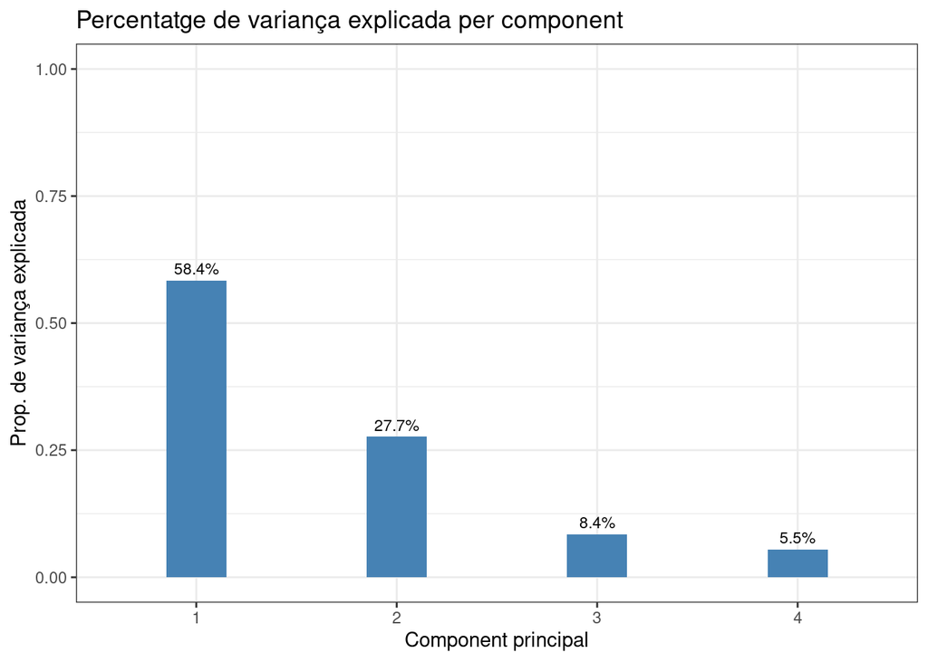

```r
# Visualitzo les proporcions
ggplot(data = data.frame(prop_var, pc = factor(1:4)), aes(x = pc, y = prop_var)) +
geom_col(width = 0.3, fill= "steelblue") + scale_y_continuous(limits = c(0,1)) +
geom_text(aes(label = paste0(round((prop_var * 100), 1), "%")), size = 3, vjust = -0.5, hjust = 0.5) + theme_bw() + labs(title= "Percentatge de variança explicada per component", x = "Component principal", y = "Prop. de variança explicada")
```

Veiem com el primer component explica el 58,4 % de la variança observada en les dades, el segon el 27,7 % i el tercera el 8,4% i el quart el 5,5%.

```r
# Calculo la variança explicada acumulada
cum_prop_var <- cumsum(prop_var)
cum_prop_var
```

```
## [1] 0.5840912 0.8607596 0.9451132 1.0000000
```

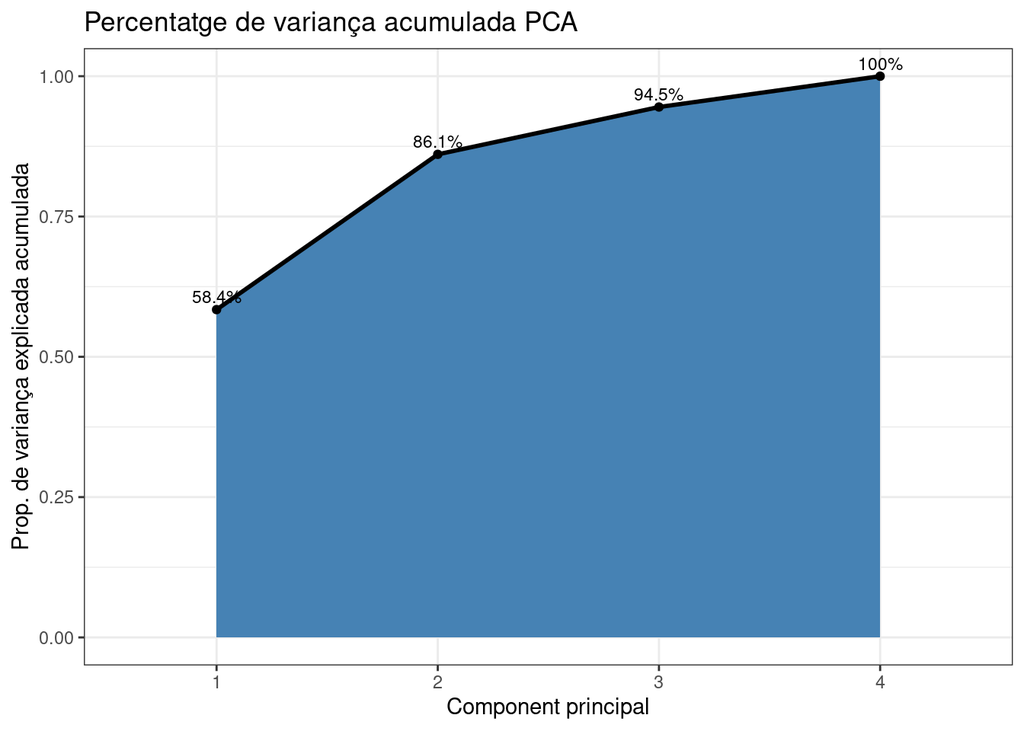

```r
# Visualitzo
ggplot(data = data.frame(cum_prop_var, pc = factor(1:4)), aes(x = pc, y = cum_prop_var, group =1)) + geom_area(fill="steelblue") + geom_point() + geom_line(size=1) + theme_bw() + geom_text(aes(label = paste0(round((cum_prop_var * 100), 1), "%")), size = 3, vjust = -0.5, hjust = 0.5) + labs(title= "Percentatge de variança acumulada PCA", x = "Component principal", y = "Prop. de variança explicada acumulada")
```

Escolliré treballar amb només els primers components, ja que expliquen el 86,1% de la variança i a partir d’aqui l’increment deixa de ser substancial.

## 6.2 Model supervisat amb PCA

```r
# Selecciono els 2 primers components
dades_pca <- pca$x[,1:2]
dades_pca <- as.data.frame(dades_pca)
# Afegeixo la columna de classe
dades_pca$genere <- dades_arbre$genere
```

Creo els conjunts d’entrenament i de validació

```r
# Selecciono el 20% de les dades per fer la validació
test <- dades_pca[-test_index,]
# Utilitzo el 80% restant per a l'entrenament del modeluse the remaining 80% of data to training and testing the models
train <- dades_pca[test_index,]
```

Realitzo l’analisi discriminant lineal

```r
# a) Entreno lda
set.seed(7)
fit.lda <- train(genere~., data=dades_pca, method="lda", metric=metrica, trControl=control)
# Visualitzo el resultat
print(fit.lda)
```

```
## Linear Discriminant Analysis
##
## 66527 samples
##     2 predictor
##    18 classes: 'Abies', 'Acer', 'Alnus', 'Arbutus', 'Betula', 'Celtis', 'Corylus', 'Crataegus', 'Fagus', 'Fraxinus', 'Juniperus', 'Olea', 'Pinus', 'Populus', 'Prunus', 'Quercus', 'Salix', 'Sorbus'
##
## No pre-processing
## Resampling: Cross-Validated (10 fold)
## Summary of sample sizes: 59874, 59874, 59874, 59874, 59873, 59872, ...
## Resampling results:
##
##   Accuracy   Kappa
##   0.7230748  0.0703387
```

```r
# defineixo la columna genere com a factor
test$genere <- as.factor(test$genere)
# Genero les prediccions amb el model
predictions <- predict(fit.lda, test)
# Genero la matriu de confusio
confusionMatrix(predictions, test$genere)
```

```
## Confusion Matrix and Statistics
##
##            Reference
## Prediction  Abies Acer Alnus Arbutus Betula Celtis Corylus Crataegus Fagus
##   Abies       176    0     0       0      0      0       0         0    30
##   Acer          0    0     0       0      0      0       0         0     0
##   Alnus         0    0     0       0      0      0       0         0     0
##   Arbutus       0    0     0       0      0      0       0         0     0
##   Betula        0    0     0       0      0      0       0         0     0
##   Celtis        0    0     0       0      0      0       0         0     0
##   Corylus       0    0     0       0      0      0       0         0     0
##   Crataegus     0    0     0       0      0      0       0         0     0
##   Fagus         3    0     0       0      0      0       0         0     3
##   Fraxinus      0    0     0       0      0      0       0         0     0
##   Juniperus     0    0     0       0      0      0       0         0     0
##   Olea          0    0     0       0      0      0       0         0     0
##   Pinus       533   33    15       9    208      7      16         6   149
##   Populus       0    0     0       0      0      0       0         0     0
##   Prunus        0    0     0       0      0      0       0         0     0
##   Quercus       5    1     0       0      9      0       3         0     6
##   Salix         0    0     0       0      0      0       0         0     0
##   Sorbus        0    0     0       0      0      0       0         0     0
##            Reference
## Prediction  Fraxinus Juniperus Olea Pinus Populus Prunus Quercus Salix Sorbus
##   Abies            2         0    0   144      22      0      20     0      0
##   Acer             0         0    0     0       0      0       0     0      0
##   Alnus            0         0    0     0       0      0       0     0      0
##   Arbutus          0         0    0     0       0      0       0     0      0
##   Betula           0         0    0     0       0      0       0     0      0
##   Celtis           0         0    0     0       0      0       0     0      0
##   Corylus          0         0    0     0       0      0       0     0      0
##   Crataegus        0         0    0     0       0      0       0     0      0
##   Fagus            0         0    0     7       0      0       0     0      0
##   Fraxinus         0         0    0     0       0      0       0     0      0
##   Juniperus        0         0    0     0       0      0       0     0      0
##   Olea             0         0    0     0       0      0       0     0      0
##   Pinus           63        38    7  9401      74      6    1875    16     30
##   Populus          0         0    0     0       0      0       0     0      0
##   Prunus           0         0    0     0       0      0       0     0      0
##   Quercus          3         1    1   330       2      1      34     1      1
```

[output cut: 46 more lines]

```
## Pos Pred Value                    NaN         NaN      0.75292            NaN
## Neg Pred Value               0.997066   0.9993981      0.40248       0.992627
## Prevalence                   0.002934   0.0006019      0.74351       0.007373
## Detection Rate               0.000000   0.0000000      0.70732       0.000000
## Detection Prevalence         0.000000   0.0000000      0.93943       0.000000
## Balanced Accuracy            0.500000   0.5000000      0.52318       0.500000
##                      Class: Prunus Class: Quercus Class: Salix Class: Sorbus
## Sensitivity              0.0000000       0.017626     0.000000      0.000000
## Specificity              1.0000000       0.967963     1.000000      1.000000
## Pos Pred Value                 NaN       0.085427          NaN           NaN
## Neg Pred Value           0.9994733       0.853021     0.998721      0.997668
## Prevalence               0.0005267       0.145136     0.001279      0.002332
## Detection Rate           0.0000000       0.002558     0.000000      0.000000
## Detection Prevalence     0.0000000       0.029945     0.000000      0.000000
## Balanced Accuracy        0.5000000       0.492795     0.500000      0.500000
```